# Analysis and estimation of factors associated with Obesity

STAT 420, Final Project Report

Adam Goodell

Joel Dazo

Rahul Sharma

# 1. Introduction

The goal of this project is to analyze and estimate the factors associated with the obesity. Obesity is one of the major problems in the current generation and has been growing steadily. There are many scientific publications over the past few years, specifically concentrating on the factors included in this project’s dataset that is used largely in software industry to build better tools.

We chose this research topic after analyzing the facts from WHO about obesity [2]:

- Worldwide obesity has nearly tripled since 1975.
- In 2016, more than 1.9 billion adults, 18 years and older, were overweight. Of these over 650 million were obese.
- 39% of adults aged 18 years and over were overweight in 2016, and 13% were obese.
- Most of the world’s population live in countries where overweight and obesity kills more people than underweight.
- 39 million children under the age of 5 were overweight or obese in 2020.
- Over 340 million children and adolescents aged 5-19 were overweight or obese in 2016.

The source our research project is the paper published by Fabio Mendoza Palcechor, this paper presents data for the estimation of obesity levels in individuals from the countries of Mexico, Peru and Colombia [1] and we acquired the dataset from the UCI Machine Learning Repository [3]. The dataset contains numerical, ordinal and categorical attributes and has sufficient observations for regression study that fulfills this course requirement. Further, this dataset is represented as comma-separated values with `17` variables or attributes and `2,111` records. It’s made available in CSV format as well as in an Attribute-Relation File Format (ARFF) format for use with the Weka machine learning software.

The dataset can be accessed and downloaded by following this link.

*Primarily our aim is to explore these topics but not limited to*

- Estimation of the obesity level of individuals using various eating habits.
- Estimation of the obesity level of individuals using various physical conditions.
- How other variables are associated with the Obesity Gender, Age, Height and Weight impacts.
- Build the model to predict Weights and Obesity levels using linear regression and logistic regression respectively.

In addition to predicting weight, our research metrics about obesity and body mass index (BMI) shall be compared with the baseline published by Mendoza and WHO [1]:

- Underweight Less than 18.5
- Normal 18.5 to 24.9
- Overweight 25.0 to 29.9
- Obesity I 30.0 to 34.9
- Obesity II 35.0 to 39.9
- Obesity III Higher than 40

This project report encompasses topics-

- Data cleaning
- Multiple linear regression
- ANOVA
- Dummy variables
- Interaction
- Residual diagnostics
- Outlier diagnostics
- Transformations
- Polynomial regression
- Stepwise model selection
- Variable selection

*Load dataset*

```r
#obesity=read.arff("data/Obesity.arff");
obesity=readRDS("data/obesity.Rda")
#obesity$NCP=as.factor(as.integer(obesity$NCP))
dim(obesity)
```

```
## [1] 2111   17
```

```r
load_cleansed=function(){
  obesity=read.csv("data/obesity_cleaned.csv")
  obesity$gender=as.factor(as.integer(obesity$gender))
  obesity$famhist=as.factor(as.integer(obesity$famhist))
  obesity$favc=as.factor(as.integer(obesity$favc))
  obesity$fcvc=as.factor(as.integer(obesity$fcvc))
  obesity$ncp=as.factor(as.integer(obesity$ncp))
  obesity$caec=as.factor(as.integer(obesity$caec))
  obesity$smoke=as.factor(as.integer(obesity$smoke))
  obesity$scc=as.factor(as.integer(obesity$scc))
  obesity$faf=as.factor(as.integer(obesity$faf))
  obesity$tue=as.factor(as.integer(obesity$tue))
  obesity$calc=as.factor(as.integer(obesity$calc))
  obesity$mtrans=as.factor(as.integer(obesity$mtrans))
  obesity$mot=as.factor(as.integer(obesity$mot))
  obesity$wstatus=as.factor(as.integer(obesity$wstatus))

}
```

*Provided predictors*

```r
str(obesity)
```

```
## 'data.frame':    2111 obs. of  17 variables:
##  $ Gender                        : Factor w/ 2 levels "Female","Male": 1 1 2 2 2 2 1 2 2 2 ...
##  $ Age                           : num  21 21 23 27 22 29 23 22 24 22 ...
##  $ Height                        : num  1.62 1.52 1.8 1.8 1.78 1.62 1.5 1.64 1.78 1.72 ...
##  $ Weight                        : num  64 56 77 87 89.8 53 55 53 64 68 ...
##  $ family_history_with_overweight: Factor w/ 2 levels "yes","no": 1 1 1 2 2 2 1 2 1 1 ...
##  $ FAVC                          : Factor w/ 2 levels "yes","no": 2 2 2 2 2 1 1 2 1 1 ...
##  $ FCVC                          : num  2 3 2 3 2 2 3 2 3 2 ...
##  $ NCP                           : Factor w/ 4 levels "1","2","3","4": 3 3 3 3 1 3 3 3 3 3 ...
##  $ CAEC                          : Factor w/ 4 levels "no","Sometimes",..: 2 2 2 2 2 2 2 2 2 2 ...
##  $ SMOKE                         : Factor w/ 2 levels "yes","no": 2 1 2 2 2 2 2 2 2 2 ...
##  $ CH2O                          : num  2 3 2 2 2 2 2 2 2 2 ...
##  $ SCC                           : Factor w/ 2 levels "yes","no": 2 1 2 2 2 2 2 2 2 2 ...
##  $ FAF                           : num  0 3 2 2 0 0 1 3 1 1 ...
##  $ TUE                           : num  1 0 1 0 0 0 0 0 1 1 ...
##  $ CALC                          : Factor w/ 4 levels "no","Sometimes",..: 1 2 3 3 2 2 2 2 3 1 ...
##  $ MTRANS                        : Factor w/ 5 levels "Automobile","Motorbike",..: 4 4 4 5 4 1 2 4 4 4 ...
##  $ NObeyesdad                    : Factor w/ 7 levels "Insufficient_Weight",..: 2 2 2 3 4 2 2 2 2 2 ...
```

*Summary of each variable*

```r
summary(obesity)
```

```
##     Gender          Age           Height         Weight
##  Female:1043   Min.   :14.0   Min.   :1.45   Min.   : 39.0
##  Male  :1068   1st Qu.:19.9   1st Qu.:1.63   1st Qu.: 65.5
##                Median :22.8   Median :1.70   Median : 83.0
##                Mean   :24.3   Mean   :1.70   Mean   : 86.6
##                3rd Qu.:26.0   3rd Qu.:1.77   3rd Qu.:107.4
##                Max.   :61.0   Max.   :1.98   Max.   :173.0
##
##  family_history_with_overweight  FAVC           FCVC      NCP
##  yes:1726                       yes:1866   Min.   :1.00   1: 395
##  no : 385                       no : 245   1st Qu.:2.00   2: 285
##                                            Median :2.39   3:1362
##                                            Mean   :2.42   4:  69
##                                            3rd Qu.:3.00
##                                            Max.   :3.00
##
##          CAEC      SMOKE           CH2O       SCC            FAF
##  no        :  51   yes:  44   Min.   :1.00   yes:  96   Min.   :0.000
##  Sometimes :1765   no :2067   1st Qu.:1.58   no :2015   1st Qu.:0.124
##  Frequently: 242              Median :2.00              Median :1.000
##  Always    :  53              Mean   :2.01              Mean   :1.010
##                               3rd Qu.:2.48              3rd Qu.:1.667
##                               Max.   :3.00              Max.   :3.000
##
##       TUE                CALC                        MTRANS
##  Min.   :0.000   no        : 639   Automobile           : 457
##  1st Qu.:0.000   Sometimes :1401   Motorbike            :  11
##  Median :0.625   Frequently:  70   Bike                 :   7
##  Mean   :0.658   Always    :   1   Public_Transportation:1580
##  3rd Qu.:1.000                     Walking              :  56
##  Max.   :2.000
##
##                NObeyesdad
##  Insufficient_Weight:272
##  Normal_Weight      :287
##  Overweight_Level_I :290
##  Overweight_Level_II:290
##  Obesity_Type_I     :351
##  Obesity_Type_II    :297
##  Obesity_Type_III   :324
```

# 2. Methods

## 2.1. Exploratory Data Analysis

[figure not shown]

```r
pairs(obesity)
```

*Data distribution by Age, Gender and Mode of transportation*

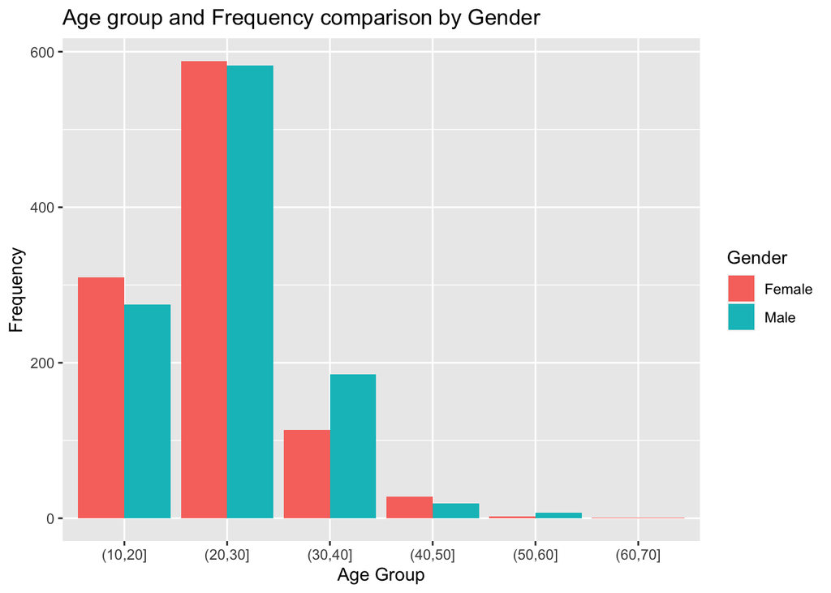

```r
obesity=obesity%>%mutate(ageBins = cut(Age, breaks = seq(0,100,by=10)))
age_agg=obesity %>% count(ageBins,Gender)
ggplot(age_agg, aes(ageBins, n, fill = Gender)) +
  geom_col(position = 'dodge')+
    xlab("Age Group")+
    ylab("Frequency")+
    ggtitle("Age group and Frequency comparison by Gender")
```

On the plot majority of the observations are between 10 to 40 age range and 20-30 group has maximum number of records records.

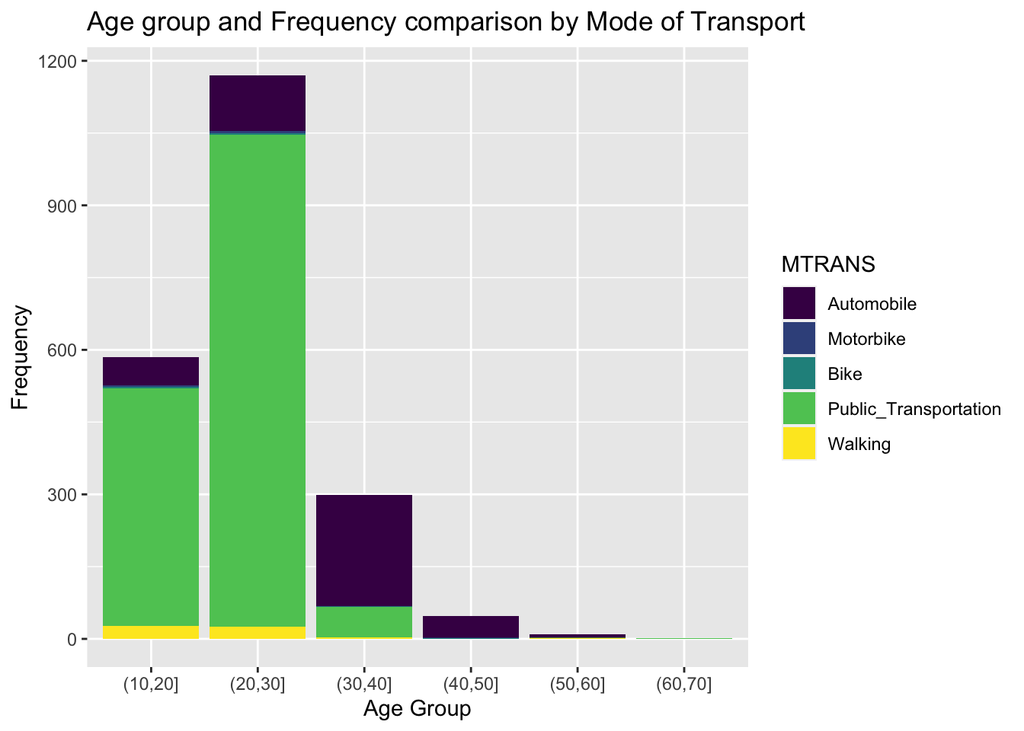

```r
age_mot_agg=obesity %>% count(ageBins,MTRANS)
ggplot(age_mot_agg, aes(fill=MTRANS,y=n, x=ageBins)) +
    geom_bar(position="stack", stat="identity") +
    scale_fill_viridis(discrete = T) +
    xlab("Age Group")+
    ylab("Frequency")+
    ggtitle("Age group and Frequency comparison by Mode of Transport")
```

Graph shows interesting factors about mode of transportation, majority of people under 30 prefer `Public transport` and conversely, above 30 prefer `Automobile` for transport.

*Attributes related with eating habits analysis:*

- Frequent consumption of high caloric food (FAVC)
- Frequency of consumption of vegetables (FCVC)
- Number of main meals (NCP)
- Consumption of food between meals (CAEC)
- Consumption of water daily (CH20)
- Consumption of alcohol (CALC)

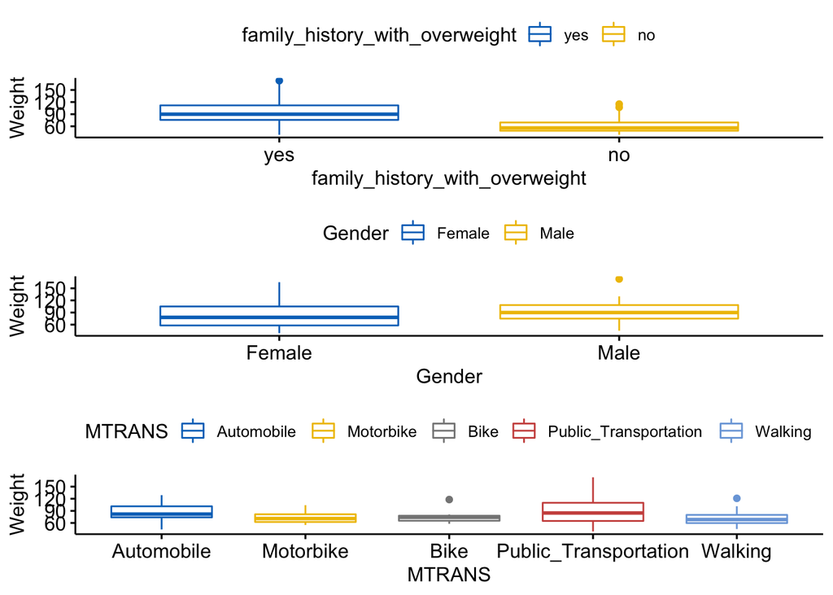

```r
p1 = ggboxplot(obesity, x = "family_history_with_overweight", y = "Weight",
    color = "family_history_with_overweight", palette = "jco")
p2 = ggboxplot(obesity, x = "Gender", y = "Weight",
    color = "Gender", palette = "jco")
p3=ggboxplot(obesity, x = "MTRANS", y = "Weight",
    color = "MTRANS", palette = "jco")
p4=ggboxplot(obesity, x = "FAVC", y = "Weight",
    color = "FAVC", palette = "jco")+
    xlab("FAVC")
p5=ggboxplot(obesity, x = "NCP", y = "Weight",
    color = "NCP", palette = "jco")+
    xlab("NCP")
p6=ggboxplot(obesity, x = "CAEC", y = "Weight",
    color = "CAEC", palette = "jco")+
    xlab("CAEC")
p7=ggboxplot(obesity, x = "SMOKE", y = "Weight",
    color = "SMOKE", palette = "jco")+
    xlab("SMOKE")
ggarrange(p1,p2,p3,nrow=3,ncol=1)
```

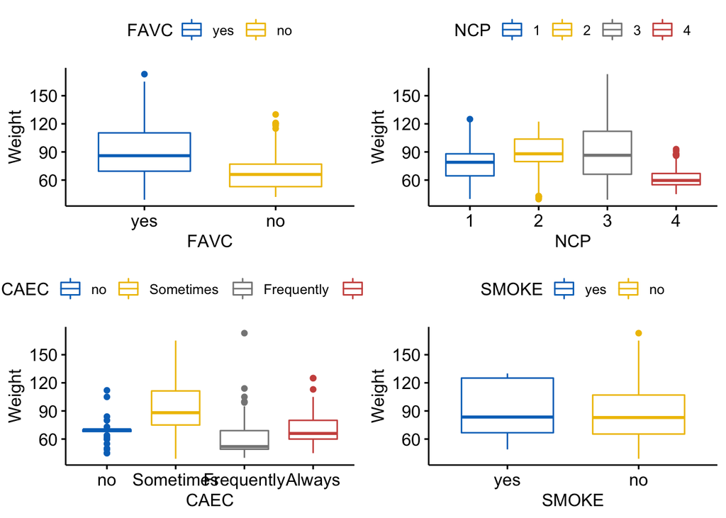

```r
ggarrange(p4,p5,p6,p7,nrow=2,ncol=2)
```

Plot shows categorical variables related to eating habits have relationship with Weight.

```r
ggplot(obesity, aes(x=Age, color=Gender)) +
  geom_histogram(fill="white", position="dodge")+
  theme(legend.position="top")
```

[output not shown]

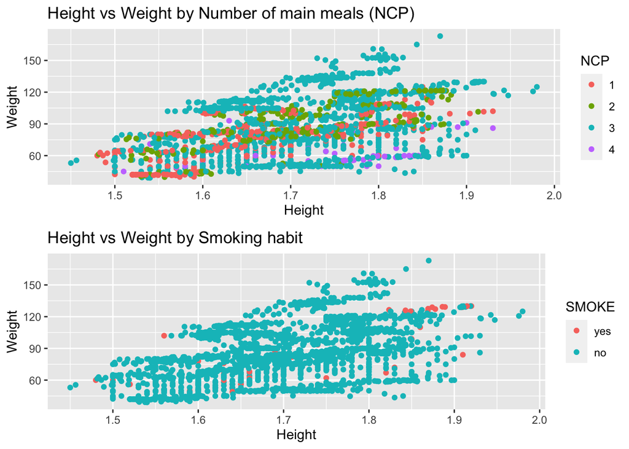

```r
p1=ggplot(data = obesity) +
  geom_point(mapping = aes(x = Height, y = Weight,color=NCP))+
  ggtitle("Height vs Weight by Number of main meals (NCP) ")
p2=ggplot(data = obesity) +
  geom_point(mapping = aes(x = Height, y = Weight,color=SMOKE))+
  ggtitle("Height vs Weight by Smoking habit")
ggarrange(p1,p2,nrow=2,ncol=1)
```

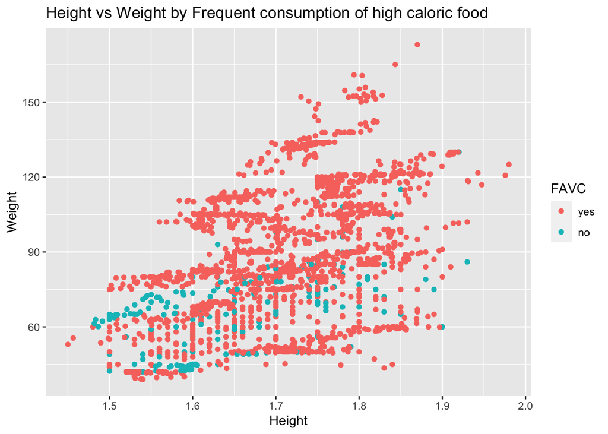

```r
ggplot(data = obesity) +
  geom_point(mapping = aes(x = Height, y = Weight,color=FAVC))+
  ggtitle("Height vs Weight by Frequent consumption of high caloric food")
```

*Attributes related with the physical condition are:*

- Calories consumption monitoring (SCC)

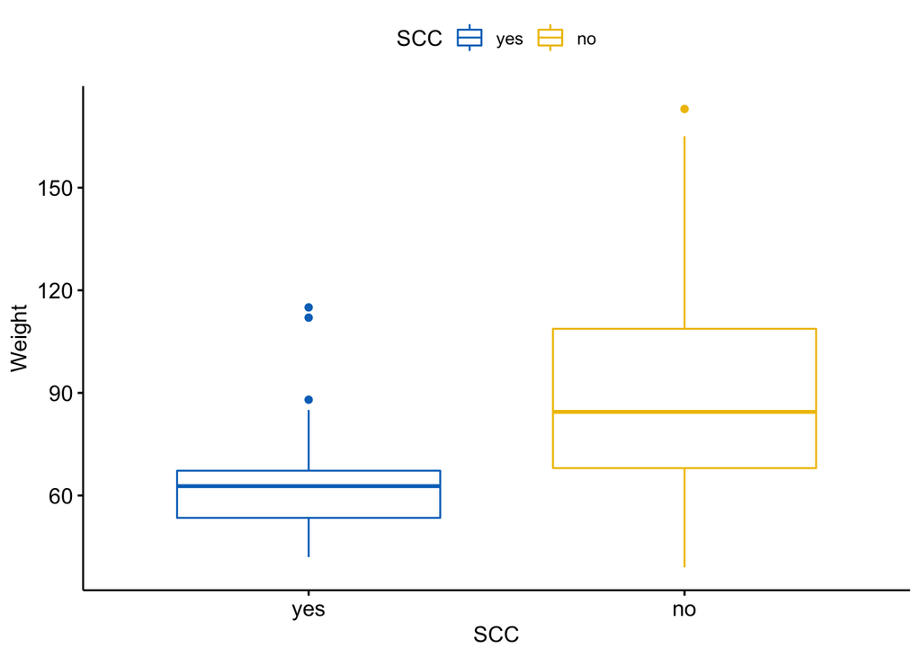

```r
ggboxplot(obesity, x = "SCC", y = "Weight",
    color = "SCC", palette = "jco")
```

Above depicts people monitoring calories consumption are more likely to be fit.

## 2.2. Common functions to perform model diagnostics

*Split dataset test and traint*

```r
set.seed(04082021)
## 75% of the sample size
smp_size <- floor(0.75 * nrow(obesity))
## set the seed to make your partition reproducible
trn_ind <- sample(seq_len(nrow(obesity)), size = smp_size)
obs_trn <- obesity[trn_ind, ]
obs_test <- obesity[-trn_ind, ]
```

*Useful functions*

```r
#' Generate plots for regression assumptions- Linearity, Normality and Equal variance
#' i.e. Fitted vs Residual, QQ Plot, Residuals histogram
#' @param obs_mod A model for plots

plot_diagnostics=function (model){
  par(mfrow = c(2, 2))
  title=paste("Data from model: \n",summary(model)$call[2], summary(model)$call[3])
  plot(fitted(model), resid(model),pch = 20,  cex.main=1,cex.lab=1,xlab = "Fitted", ylab = "Residuals")
  abline(h = 0, lty = 2, lwd = 2, col="darkorange")
  qqnorm(resid(model), main = "Normal Q-Q Plot", col = "darkgrey")
  qqline(resid(model), col = "dodgerblue", lwd = 2)
  hist(resid(model),
       xlab   = "Residuals",
       main   = "Histogram of Residuals",
       col    = "darkorange",
       border = "dodgerblue",
       breaks = 20)
}

#' Return model performance metrics
#' R2, Adj R2,Train_RMSE, Test_RMSE, BPTEST, SP Test
#
#' @param obs_mod A model for metrics is required
#' @param test dataset- used to calculate test RMSE. Default value is obesity test data

mod_performance=function(obs_mod,obs_tst=obs_test){
  smry=summary(obs_mod)
  #Train RMSE
  trn_rmse=sqrt(mean(resid(obs_mod)^2))
  pred=predict(obs_mod,newdata=obs_tst)
  #test RMSE
  tst_rmse=sqrt(mean((obs_tst$Weight-pred)^2))
  scores=list(r2=smry$r.squared
       ,adjr2=smry$adj.r.squared,
       Train_rmse=trn_rmse,Test_rmse=tst_rmse,
       bptest=bptest(obs_mod)$p.value
       ,sptest=shapiro.test(resid(obs_mod))$p.value)

  unlist(scores, recursive = TRUE, use.names = TRUE)
}
```

## 2.3. Model Diagnostics, Performance and Selection

### Model1- Additive model with all the parameters

```r
obs_mod_add=lm(Weight~.-NObeyesdad-ageBins,data=obs_trn)
summary(obs_mod_add)
```

```
##
## Call:
## lm(formula = Weight ~ . - NObeyesdad - ageBins, data = obs_trn)
##
## Residuals:
##    Min     1Q Median     3Q    Max
## -50.16 -11.84   1.68   9.76  52.94
##
## Coefficients:
##                                   Estimate Std. Error t value Pr(>|t|)
## (Intercept)                      -176.1376    11.5721  -15.22  < 2e-16 ***
## GenderMale                         -4.1501     1.1639   -3.57  0.00037 ***
## Age                                 0.8963     0.0918    9.77  < 2e-16 ***
## Height                            118.9925     6.6051   18.02  < 2e-16 ***
## family_history_with_overweightno  -18.2372     1.2503  -14.59  < 2e-16 ***
## FAVCno                             -6.0347     1.4462   -4.17  3.2e-05 ***
## FCVC                                8.7980     0.8467   10.39  < 2e-16 ***
## NCP2                                3.3192     1.5592    2.13  0.03343 *
## NCP3                                3.6556     1.1722    3.12  0.00185 **
## NCP4                               -2.0043     2.7235   -0.74  0.46189
## CAECSometimes                       1.4936     2.9715    0.50  0.61529
## CAECFrequently                    -17.6908     3.2219   -5.49  4.7e-08 ***
## CAECAlways                         -6.5737     3.9563   -1.66  0.09680 .
## SMOKEno                             0.2434     2.7288    0.09  0.92894
## CH2O                                2.2199     0.7440    2.98  0.00289 **
## SCCno                               5.4076     2.2151    2.44  0.01475 *
## FAF                                -2.1187     0.5503   -3.85  0.00012 ***
## TUE                                -1.4312     0.7572   -1.89  0.05892 .
## CALCSometimes                       7.2048     1.0010    7.20  9.5e-13 ***
## CALCFrequently                      3.7789     2.5473    1.48  0.13814
## CALCAlways                         15.6780    16.9977    0.92  0.35648
## MTRANSMotorbike                    15.4205     5.7206    2.70  0.00710 **
## MTRANSBike                         -1.0700     9.8207   -0.11  0.91325
## MTRANSPublic_Transportation        13.0282     1.3378    9.74  < 2e-16 ***
## MTRANSWalking                       3.4846     2.8858    1.21  0.22742
## ---
## Signif. codes:  0 '***' 0.001 '**' 0.01 '*' 0.05 '.' 0.1 ' ' 1
##
## Residual standard error: 16.7 on 1558 degrees of freedom
## Multiple R-squared:  0.602,  Adjusted R-squared:  0.596
## F-statistic: 98.1 on 24 and 1558 DF,  p-value: <2e-16
```

Note: we have removed drived variables agebins, NObeyesdad

```r
mod_performance(obs_mod_add)
```

```
##         r2      adjr2 Train_rmse  Test_rmse  bptest.BP     sptest
##  6.018e-01  5.957e-01  1.654e+01  1.771e+01  3.049e-42  1.807e-06
```

Next, we will look at unusual observations-

*Outliers* analysis using the cook’s distance

```r
sum(cooks.distance(obs_mod_add)>4/nrow(obs_mod_add))
```

```
## [1] 0
```

*Unusual observations using hatvalues*

```r
#We can not remove the records based on leverage as it's considering critical records as unusual
htval=hatvalues(obs_mod_add)
obs_mod_add_unusual_observations=obs_trn[(htval < 2 * mean(htval)),]
```

Further we explore the *Variable selection* methods AIC, BIC, Exhastive search to find the best model

- AIC search in both directions
- BIC Search in both directions
- Variable selection

```r
obs_mod_add_aic=step(obs_mod_add,direction="both",trace=0)
obs_mod_add_bic=step(obs_mod_add,direction="both",trace=0,k=log(nrow(obs_trn)))
p1=mod_performance(obs_mod_add_aic)
p2=mod_performance(obs_mod_add_bic)
p1=append(p1,unlist(list(num_predictors=length(coef(obs_mod_add_aic)))))
p2=append(p2,unlist(list(num_predictors=length(coef(obs_mod_add_bic)))))
mod1_stats=data.frame(obs_mod_add_aic=p1,obs_mod_add_bic=p2)
kable(mod1_stats)
```

|  | obs_mod_add_aic | obs_mod_add_bic |
| --- | --- | --- |
| r2 | 0.6018 | 0.5960 |
| adjr2 | 0.5960 | 0.5914 |
| Train_rmse | 16.5406 | 16.6606 |
| Test_rmse | 17.7063 | 17.8941 |
| bptest.BP | 0.0000 | 0.0000 |
| sptest | 0.0000 | 0.0000 |
| num_predictors | 24.0000 | 19.0000 |

*Exhaustive search*

```r
library(leaps)
obs_mod_ex_search = summary(regsubsets(Weight ~ .-NObeyesdad-ageBins, data = obesity))
obs_mod_ex_search$which
```

[output not shown]

Quantifies the effect of collinearity using *Variance Inflation Factor*-

```r
library(faraway)
kable(vif(obs_mod_add))
```

|  | x |
| --- | --- |
| GenderMale | 1.929 |
| Age | 1.987 |
| Height | 2.157 |
| family_history_with_overweightno | 1.339 |
| FAVCno | 1.183 |
| FCVC | 1.176 |
| NCP2 | 1.631 |
| NCP3 | 1.782 |
| NCP4 | 1.292 |
| CAECSometimes | 6.795 |
| CAECFrequently | 5.842 |
| CAECAlways | 2.195 |
| SMOKEno | 1.070 |
| CH2O | 1.192 |
| SCCno | 1.116 |
| FAF | 1.247 |
| TUE | 1.219 |
| CALCSometimes | 1.259 |
| CALCFrequently | 1.152 |
| CALCAlways | 1.039 |
| MTRANSMotorbike | 1.054 |
| MTRANSBike | 1.039 |
| MTRANSPublic_Transportation | 1.925 |
| MTRANSWalking | 1.282 |

Nothing major is observed from VIF scores.

Further, we check if **Transformations** is required on the response variable. We will use *Box-Cox* Transformations that considers a family of transformations on positive response variable.

```r
library(MASS)
```

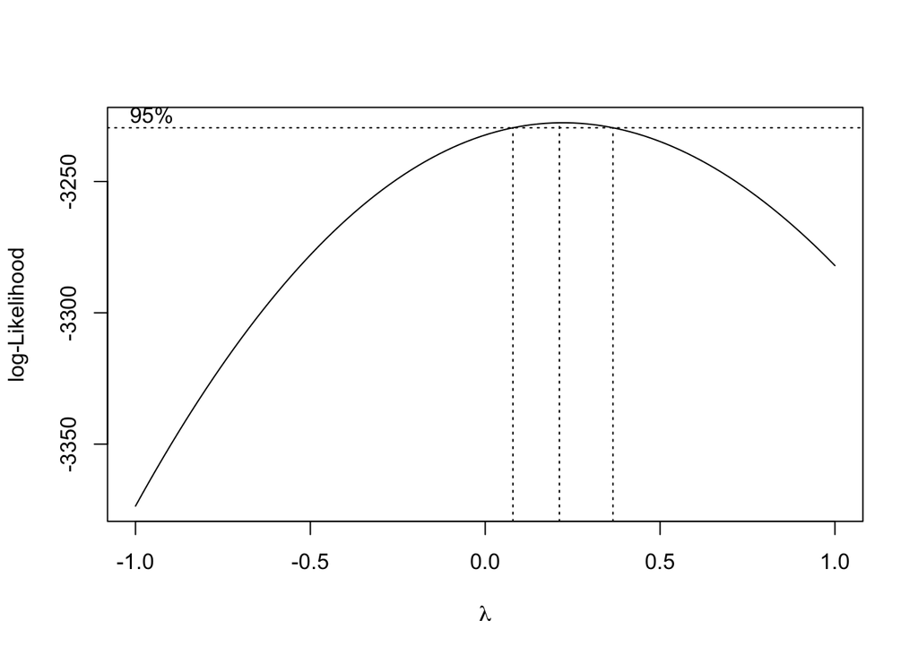

```r
library(faraway)
boxcox(obs_mod_add, plotit = TRUE,lambda = seq(-1, 1, by = 0.1))
```

```r
obs_mod_add_trns=lm((((Weight^0.2)-1)/0.2)~Gender+Age+Height+family_history_with_overweight+FAVC+FCVC+CAEC+SMOKE+FAF+CALC+MTRANS,data=obs_trn)
summary(obs_mod_add_trns)$r.squared
```

```
## [1] 0.6134
```

```r
summary(obs_mod_add_trns)$adj.r.squared
```

```
## [1] 0.6089
```

We observe slight performance improvement. We will be trying this approach on further models

### Model2- with two-way intreractions between variables

At this stage we perform the following tasks

- Build model using two-way Interactions
- Variable selection using AIC in both direction
- Variable selection using BIC in both direction
- Present scores in tabular format
- LINE assumptions test- Linearity, independence, Normality and Equal variance

```r
obs_int_mod2=lm(formula = Weight ~ (. - NObeyesdad -ageBins)^2, data = obs_trn)
obs_int_mod2_aic=step(obs_int_mod2,direction="both",trace=0)
obs_int_mod2_bic=step(obs_int_mod2,direction="both",trace=0,k=log(nrow(obs_trn)))
p1=mod_performance(obs_int_mod2_aic)
p2=mod_performance(obs_int_mod2_bic)
p1=append(p1,unlist(list(num_predictors=length(coef(obs_int_mod2_aic)))))
p2=append(p2,unlist(list(num_predictors=length(coef(obs_int_mod2_bic)))))
mod2_stats=data.frame(obs_int_mod2_aic=p1,obs_int_mod2_bic=p2)
kable(mod2_stats)
```

|  | obs_int_mod2_aic | obs_int_mod2_bic |
| --- | --- | --- |
| r2 | 0.8280 | 0.7891 |
| adjr2 | 0.8085 | 0.7786 |
| Train_rmse | 10.8729 | 12.0371 |
| Test_rmse | 15.6633 | 14.4442 |
| bptest.BP | 0.0000 | 0.0000 |
| sptest | 0.0000 | 0.0000 |
| num_predictors | 189.0000 | 86.0000 |

```r
summary(obs_int_mod2_aic)$call
```

```
## lm(formula = Weight ~ Gender + Age + Height + family_history_with_overweight +
##     FAVC + FCVC + NCP + CAEC + SMOKE + CH2O + SCC + FAF + TUE +
##     CALC + MTRANS + Gender:Age + Gender:Height + Gender:family_history_with_overweight +
##     Gender:FCVC + Gender:NCP + Gender:CAEC + Gender:SMOKE + Gender:CH2O +
##     Gender:CALC + Gender:MTRANS + Age:FAVC + Age:FCVC + Age:NCP +
##     Age:CAEC + Age:CH2O + Age:FAF + Age:TUE + Age:CALC + Height:family_history_with_overweight +
##     Height:FAVC + Height:FCVC + Height:NCP + Height:CAEC + Height:CH2O +
##     Height:FAF + Height:TUE + Height:CALC + Height:MTRANS + family_history_with_overweight:FCVC +
##     family_history_with_overweight:NCP + family_history_with_overweight:CAEC +
##     family_history_with_overweight:SCC + family_history_with_overweight:TUE +
##     family_history_with_overweight:CALC + family_history_with_overweight:MTRANS +
##     FAVC:NCP + FAVC:CAEC + FAVC:SMOKE + FAVC:CH2O + FAVC:CALC +
##     FCVC:NCP + FCVC:CAEC + FCVC:SMOKE + FCVC:CH2O + FCVC:CALC +
##     FCVC:MTRANS + NCP:TUE + NCP:CALC + CAEC:SMOKE + CAEC:SCC +
##     CAEC:FAF + CAEC:TUE + CAEC:MTRANS + SMOKE:FAF + SMOKE:CALC +
##     SMOKE:MTRANS + CH2O:SCC + CH2O:FAF + CH2O:TUE + CH2O:MTRANS +
##     SCC:TUE + SCC:CALC + SCC:MTRANS + FAF:CALC + FAF:MTRANS +
##     TUE:MTRANS, data = obs_trn)
```

```r
mod_performance(lm(formula = Weight ~ Gender + Age + Height + family_history_with_overweight +
    FAVC + FCVC + NCP + CAEC + SMOKE + CH2O + SCC + FAF + TUE +
    CALC + MTRANS + Gender:Age + Gender:Height + Gender:family_history_with_overweight +
    Gender:FCVC + Gender:NCP + Gender:CAEC + Gender:SMOKE + Gender:CH2O +
    Gender:CALC + Gender:MTRANS + Age:FAVC + Age:FCVC + Age:NCP +
    Age:CAEC + Age:CH2O + Age:FAF + Age:TUE + Age:CALC + Height:family_history_with_overweight +
    Height:FAVC + Height:FCVC + Height:NCP + Height:CAEC + Height:CH2O +
    Height:FAF + Height:TUE + Height:CALC + Height:MTRANS + family_history_with_overweight:FCVC +
    family_history_with_overweight:NCP + family_history_with_overweight:CAEC +
    family_history_with_overweight:SCC + family_history_with_overweight:TUE +
    family_history_with_overweight:CALC + family_history_with_overweight:MTRANS +
    FAVC:NCP + FAVC:CAEC + FAVC:SMOKE + FAVC:CH2O + FAVC:CALC +
    FCVC:NCP + FCVC:CAEC + FCVC:SMOKE + FCVC:CH2O + FCVC:CALC +
    FCVC:MTRANS + NCP:TUE + NCP:CALC + CAEC:SMOKE + CAEC:SCC +
    CAEC:FAF + CAEC:TUE + CAEC:MTRANS + SMOKE:FAF + SMOKE:CALC +
    SMOKE:MTRANS + CH2O:SCC + CH2O:FAF + CH2O:TUE + CH2O:MTRANS +
    SCC:TUE + SCC:CALC + SCC:MTRANS + FAF:CALC + FAF:MTRANS +
    TUE:MTRANS, data = obs_trn))
```

```
##         r2      adjr2 Train_rmse  Test_rmse  bptest.BP     sptest
##  8.280e-01  8.085e-01  1.087e+01  1.566e+01  1.837e-06  1.580e-10
```

```r
mod_performance(lm(formula = Weight ~ Gender + Age + Height + family_history_with_overweight +
    FAVC + FCVC + NCP  + SMOKE + CH2O + SCC + FAF + TUE + MTRANS + Gender:Age + Gender:Height + Gender:family_history_with_overweight +
    Gender:FCVC + Gender:NCP + Gender:CAEC + Gender:SMOKE + Gender:CH2O +
     + Gender:MTRANS + Age:FAVC + Age:FCVC + Age:NCP +
    Age:CAEC + Age:CH2O + Age:FAF + Age:TUE +  Height:family_history_with_overweight +
    Height:FAVC + Height:FCVC + Height:NCP + Height:CAEC + Height:CH2O +
    Height:FAF + Height:TUE + + Height:MTRANS + family_history_with_overweight:FCVC +
    family_history_with_overweight:NCP + family_history_with_overweight:CAEC +
    family_history_with_overweight:SCC + family_history_with_overweight:TUE +
  family_history_with_overweight:MTRANS +
    FAVC:NCP + FAVC:CAEC + FAVC:SMOKE + FAVC:CH2O +
    FCVC:NCP + FCVC:CAEC + FCVC:SMOKE + FCVC:CH2O +
    FCVC:MTRANS + NCP:TUE +  CAEC:SMOKE + CAEC:SCC +
    CAEC:FAF + CAEC:TUE + CAEC:MTRANS + SMOKE:FAF +
    SMOKE:MTRANS + CH2O:SCC + CH2O:FAF + CH2O:TUE + CH2O:MTRANS +
    SCC:TUE  + SCC:MTRANS + + FAF:MTRANS +
    TUE:MTRANS, data = obs_trn))
```

```
##         r2      adjr2 Train_rmse  Test_rmse  bptest.BP     sptest
##  7.872e-01  7.675e-01  1.209e+01  1.568e+01  1.285e-08  1.313e-08
```

```r
obs_int_mod3=lm(formula = Weight ~ (. - NObeyesdad -ageBins)^3, data = obs_trn)
smry=summary(obs_int_mod3)
p1=list(r2=smry$r.squared
       ,adjr2=smry$adj.r.squared,
       Train_rmse=sqrt(mean(resid(obs_int_mod3)^2)),Test_rmse="NA",
       bptest=bptest(obs_int_mod3)$p.value
       ,sptest=shapiro.test(resid(obs_int_mod3))$p.value, num_predictors=length(coef(obs_int_mod3)))
mod3_stats=data.frame(obs_int_mod3=unlist(p1))
```

### Model4- Selected Intreractions model with Transformations and Outlier diagnostics

```r
obs_int_mod4=lm(Weight~Gender + Age + Height + family_history_with_overweight +
    FAVC + FCVC + NCP + CAEC + SMOKE + CH2O + SCC + FAF + TUE +
    CALC+ Gender + MTRANS+FCVC:MTRANS:family_history_with_overweight:Gender:CALC:FAVC:NCP:SCC:Height + Gender:Height + Gender:family_history_with_overweight +
    Gender:FCVC + Gender:NCP + Age:FCVC + Age:NCP +
     + Age:CH2O + Age:FAF + Age:TUE + Age:CALC + Height:family_history_with_overweight +
    family_history_with_overweight:CALC ,data=obs_trn)

smry=summary(obs_int_mod4)
p1=list(r2=smry$r.squared
       ,adjr2=smry$adj.r.squared,
       Train_rmse=sqrt(mean(resid(obs_int_mod4)^2)),Test_rmse="NA",
       bptest=bptest(obs_int_mod4)$p.value
       ,sptest=shapiro.test(resid(obs_int_mod4))$p.value, num_predictors=length(coef(obs_int_mod4)))
mod4_stats=data.frame(obs_int_mod4=unlist(p1))
```

```r
library(caret)
k_fold_modn <- train(
  Weight ~ . - NObeyesdad - ageBins, obs_trn,
  method = "lm",
  trControl = trainControl(
    method = "cv", number = 5,
    verboseIter = FALSE
  )
)

mod_performance(k_fold_modn)
```

[output not shown]

### 2.4 Model optimization

- Transformations

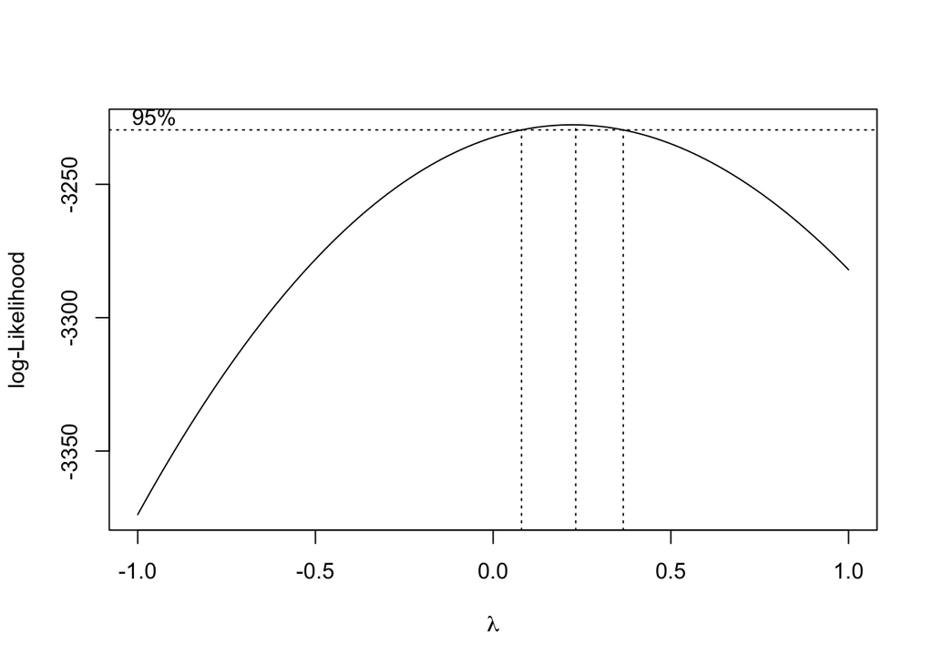

```r
boxcox(obs_mod_add_aic, plotit = TRUE,lambda = seq(-1, 1, by = 0.1))
```

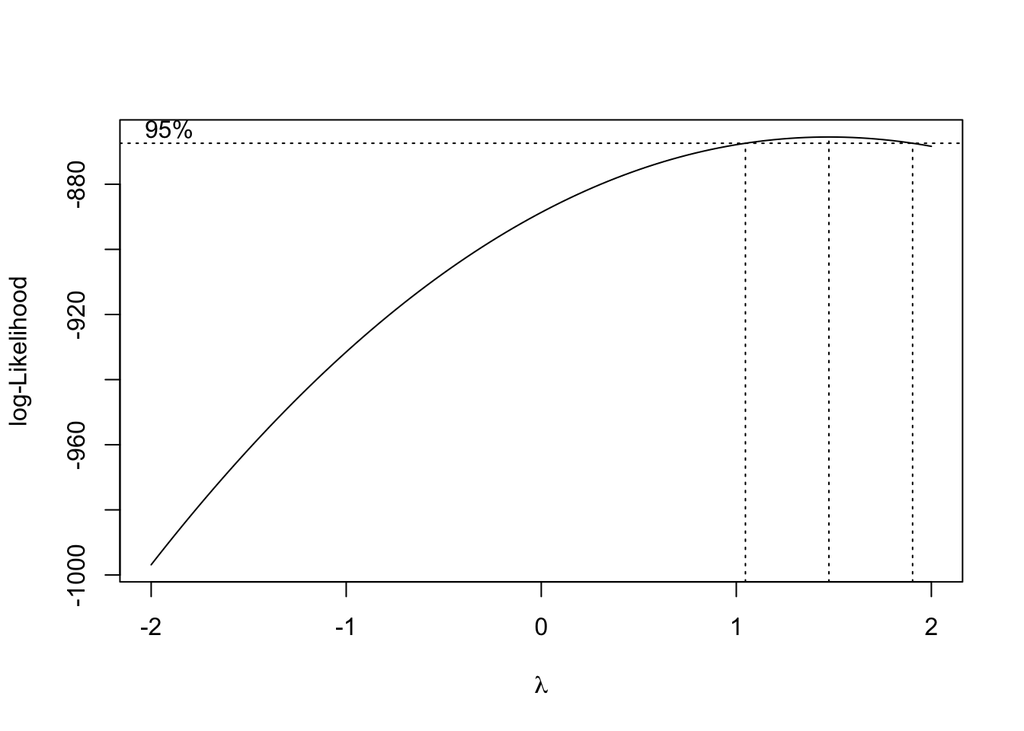

```r
obs_mod_int_trans=lm((((Weight^0.2)-1)/0.2)~(.- NObeyesdad - ageBins)^2,data=obs_trn)
boxcox(obs_mod_int_trans, plotit = TRUE)
```

This shows the transformation was not helpful on response variable.

*Leverage*

```r
#We can not remove the records based on leverage as it's considering critical records as unusual
htval=hatvalues(obs_mod_int_trans)
obs_leverages=obs_trn[(htval > 2 * mean(htval)),]
```

*Outliers*

```r
outliers=cooks.distance(obs_int_mod2_aic)>4/length(resid(obs_int_mod2_aic))
obs_outliers=obs_trn[outliers,]
```

# 3. Results

In the previous section we developed multiple models and use various strategies to improve the overall model performance. Next, our goal perform model diagnostics and performance analysis.

## 3.1 Anova test

Total number of comparisons *Model 1 & 2 comparison*

- Model 1: null model `obs_mod_add`

Number of parameters: 25

- Model 2: full model `obs_int_mod2_aic`

Number of parameters: 189

```r
anova(obs_mod_add,obs_int_mod2_aic)[2,"Pr(>F)"]<0.01
```

```
## [1] TRUE
```

We reject null hypothesis $H_0$ at significance $\alpha =0.01$. We prefer the interaction model `obs_int_mod2_aic` over the additive model.

## 3.2 Model Diagnostics

```r
p1=mod_performance(obs_mod_add)
p2=mod_performance(obs_int_mod2_aic)
p1=append(p1,unlist(list(num_predictors=length(coef(obs_mod_add)))))
p2=append(p2,unlist(list(num_predictors=length(coef(obs_int_mod2_aic)))))
kable(data.frame(obs_mod_add=p1,obs_int_mod2_aic=p2))
```

|  | obs_mod_add | obs_int_mod2_aic |
| --- | --- | --- |
| r2 | 0.6018 | 0.8280 |
| adjr2 | 0.5957 | 0.8085 |
| Train_rmse | 16.5406 | 10.8729 |
| Test_rmse | 17.7065 | 15.6633 |
| bptest.BP | 0.0000 | 0.0000 |
| sptest | 0.0000 | 0.0000 |
| num_predictors | 25.0000 | 189.0000 |

Observations are-

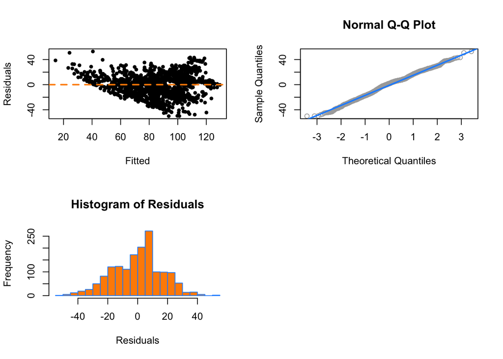

```r
plot_diagnostics(obs_mod_add)
```

On the Residuals vs Fitted plot, the residuals spread is not bounce constantly both side of the horizontal 0 line, we suspect Linearity assumption. Also, we would suspect constant variance assumption as residuals spreads changes with increase in fitted value.

Residuals don’t follow normal distribution.

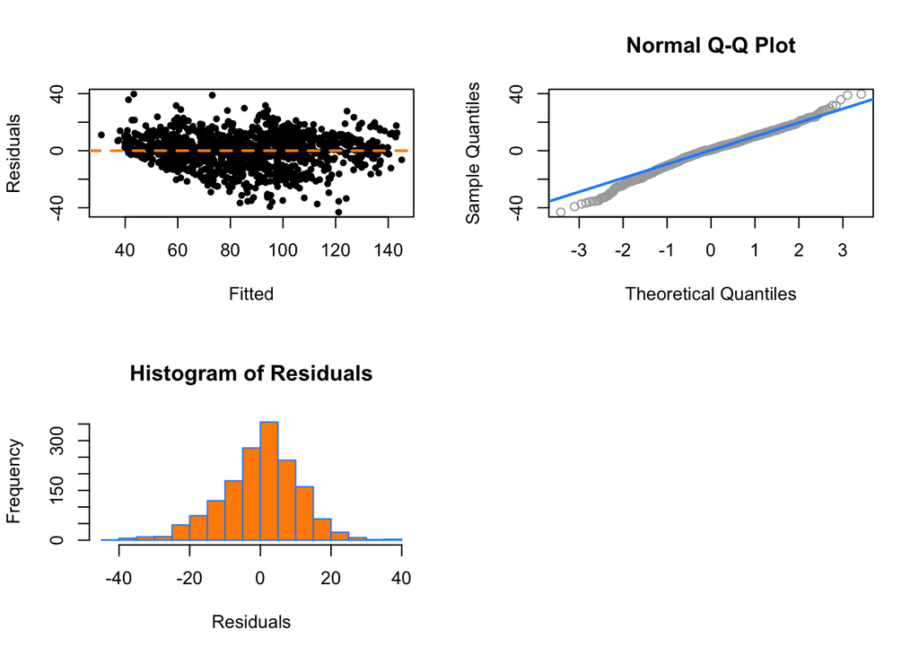

```r
plot_diagnostics(obs_int_mod2_aic)
```

## 3.3 The big picture from all models

```r
kable(cbind(mod1_stats,mod2_stats,mod3_stats,mod4_stats))
```

|  | obs_mod_add_aic | obs_mod_add_bic | obs_int_mod2_aic | obs_int_mod2_bic | obs_int_mod3 | obs_int_mod4 |
| --- | --- | --- | --- | --- | --- | --- |
| r2 | 0.6018 | 0.5960 | 0.8280 | 0.7891 | 0.956247391695653 | 0.840896918356098 |
| adjr2 | 0.5960 | 0.5914 | 0.8085 | 0.7786 | 0.920804775357578 | 0.815333033631216 |
| Train_rmse | 16.5406 | 16.6606 | 10.8729 | 12.0371 | 5.48311694965132 | 10.4559820874074 |
| Test_rmse | 17.7063 | 17.8941 | 15.6633 | 14.4442 | NA | NA |
| bptest.BP | 0.0000 | 0.0000 | 0.0000 | 0.0000 | 0.999999996683043 | 3.33937402032391e-07 |
| sptest | 0.0000 | 0.0000 | 0.0000 | 0.0000 | 7.92059907992404e-31 | 8.80640711371577e-14 |
| num_predictors | 24.0000 | 19.0000 | 189.0000 | 86.0000 | 1994 | 1325 |

## 3.4 Summary from diagnostics

We used HatValue to identify leverages and Cook’s distance for outliers detection in Methods section. There are 144 outliers and 223 leverages

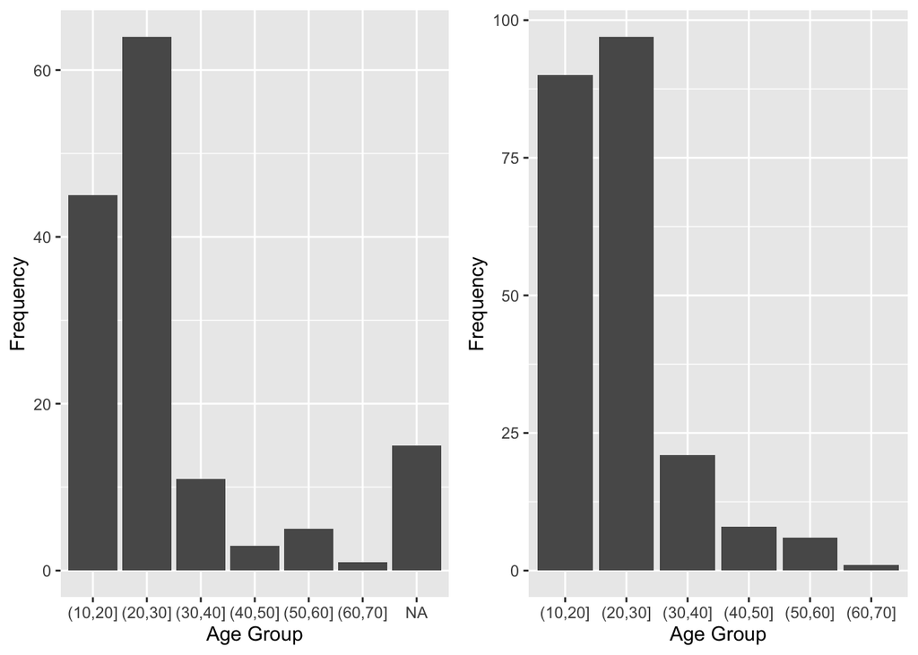

```r
age_mot_agg=obs_outliers %>% count(ageBins,MTRANS)
p1=ggplot(age_mot_agg, aes(y=n, x=ageBins)) +
    geom_bar(position="stack", stat="identity") +
    scale_fill_viridis(discrete = T) +
    xlab("Age Group")+
    ylab("Frequency")

age_mot_agg=obs_leverages %>% count(ageBins,MTRANS)
p2=ggplot(age_mot_agg, aes(y=n, x=ageBins)) +
    geom_bar(position="stack", stat="identity") +
    scale_fill_viridis(discrete = T) +
    xlab("Age Group")+
    ylab("Frequency")
ggarrange(p1,p2,nrow=1,ncol=2)
```

# 4. Discussion